# Análisis evolución Covid-19 Chile casos y decesos (12/04/2020)

Claudio Bustos

12/4/2020

- Reportes anteriores: https://github.com/clbustos/analisis_covid19_chile

**Comentario técnico**: Intenté modelar una biexponencial sobre los casos nuevos, pero no convergía el modelo. Una Gompertz si funciona, pero es demasiado optimista, ya que asume que estamos viendo el máximo punto de la crisis. Por tanto, me mantengo con los modelos que llevo hasta ahora.

## Análisis de series de casos

La serie de casos se hace hace partir de los 25 casos, excepto para Atacama y Aysén, donde se inicia del quinto caso, para facilitar la comparación desde un punto de un punto de partida común.Se mantiene la tendencia de la serie total de mantenerse en un crecimiento exponencial sostenido sin mucha desaceleraión, supongo que impulsado por la tasa constante de la metropolitana, que lleva casi 2 semanas. En otras regiones de la zona centro y Sur , como Araucanía, Ñuble y Biobío, ya observamos la clásica curva de desaceleración.

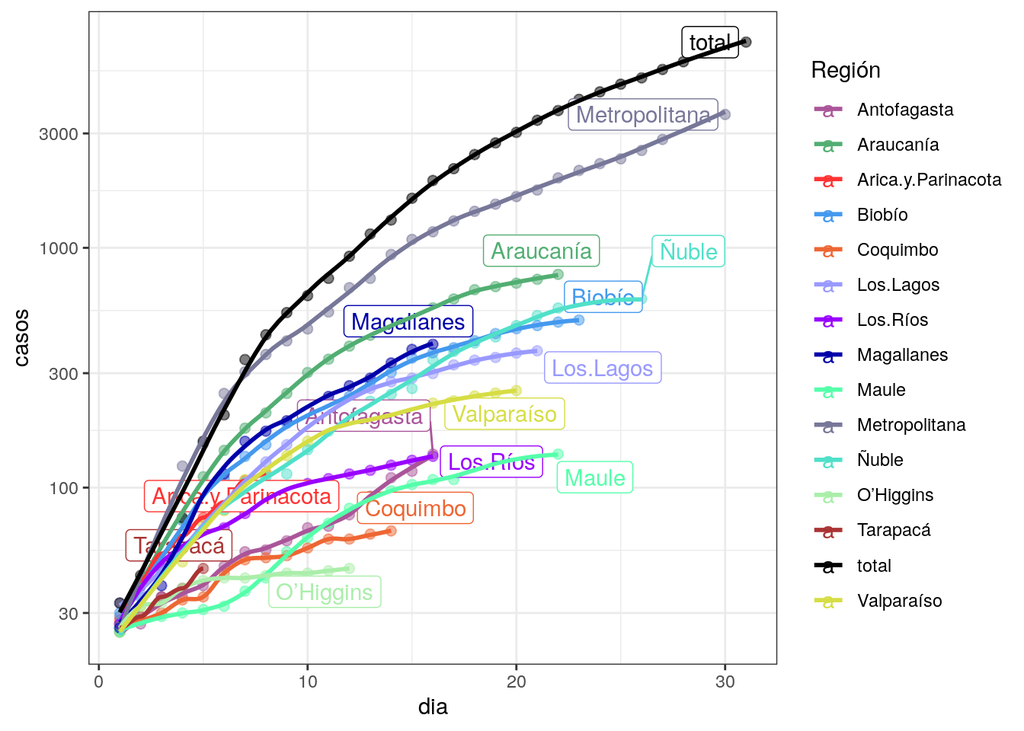

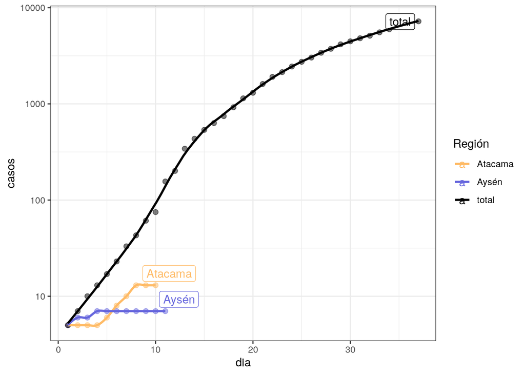

La serie por región se hace partir de los 5 primeros casos.

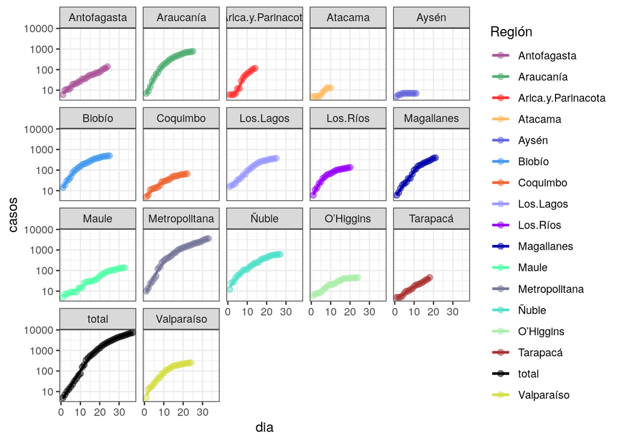

Si observamos la proporción de casos nuevos por región, observamos aceleraciones en Tarapacá y Antofagasta. La tendencia de los últimos días es a volver a desacelerar, lo cual indica que la tendencia al alza de los últimos dos o tres días puede que haya sido un influjo de nuevos casos específicos.

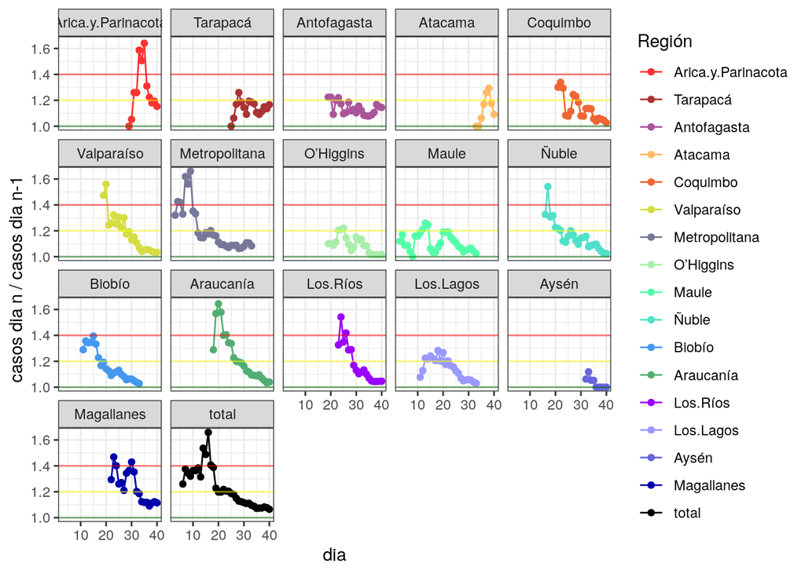

En el gráfico FSDG, se observa la inestabilidad de tasa de Arica y Parinacota, así como de Atacama.

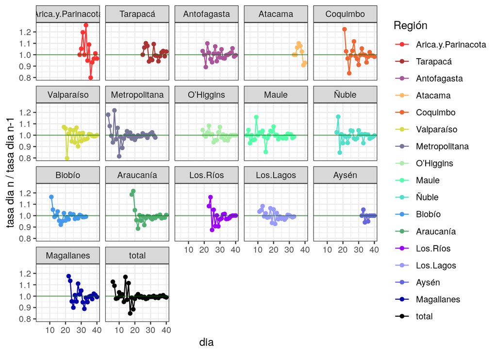

## Predicción

### Predicción para serie total

Recordemos que la regresión exponencial se eliminó, porque ya no calza con la serie total. A partir del análisis del resultado del algoritmo de la última semana, para la predicción total se recorta la serie a partir de lo 50 casos.

|  | casos | li | ls |
| --- | --- | --- | --- |
| **Observado** | 7213 | NA | NA |
| **ARIMA(1,1,0)** | 11120.84 | 5253.939 | 23539.12 |
| **T+AR(1)** | 6655.307 | 6109.595 | 7741.042 |
| **T+AR(4)** | 6723.091 | 6195.271 | 7700.514 |

Al igual que ayer, AR(1) es más pesimista que AR(4).

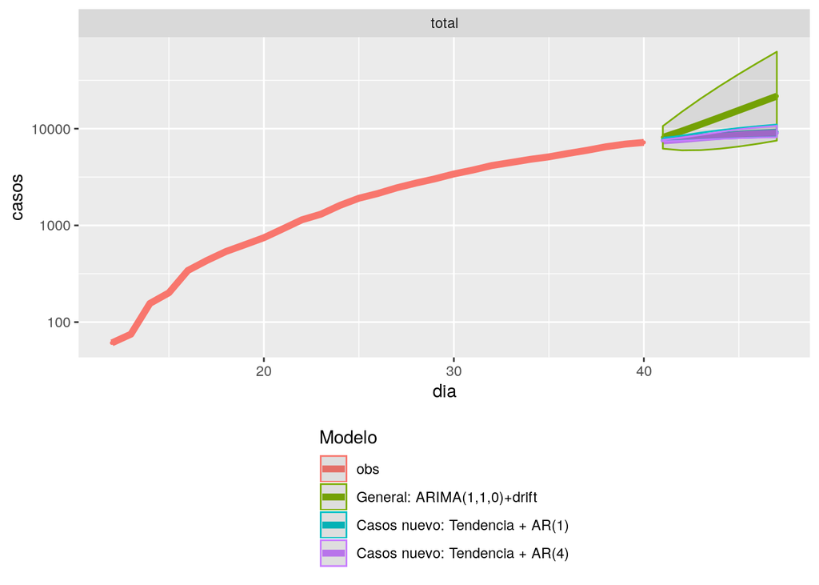

Casos nuevos: tendencia + AR(4) : total

|  | dia | casos | li | ls |
| --- | --- | --- | --- | --- |
| **30** | 41 | 7487 | 7380 | 7661 |
| **31** | 42 | 7725 | 7518 | 8071 |
| **32** | 43 | 8041 | 7696 | 8634 |
| **33** | 44 | 8332 | 7837 | 9235 |
| **34** | 45 | 8628 | 7979 | 9852 |
| **35** | 46 | 8840 | 8079 | 10301 |
| **36** | 47 | 9020 | 8161 | 10698 |

Casos nuevos: tendencia + AR(1) : total

|  | dia | casos | li | ls |
| --- | --- | --- | --- | --- |
| **30** | 41 | 7594 | 7424 | 7902 |
| **31** | 42 | 7896 | 7579 | 8490 |
| **32** | 43 | 8204 | 7734 | 9102 |
| **33** | 44 | 8476 | 7870 | 9645 |
| **34** | 45 | 8732 | 7998 | 10155 |
| **35** | 46 | 8961 | 8113 | 10613 |
| **36** | 47 | 9168 | 8217 | 11028 |

ARIMA(1,1,0) con deriva : total

|  | dia | casos | li | ls |
| --- | --- | --- | --- | --- |
| **30** | 41 | 8132 | 6213 | 10644 |
| **31** | 42 | 9448 | 5972 | 14947 |
| **32** | 43 | 11104 | 6002 | 20546 |
| **33** | 44 | 13107 | 6206 | 27686 |
| **34** | 45 | 15497 | 6540 | 36724 |
| **35** | 46 | 18334 | 6984 | 48130 |
| **36** | 47 | 21696 | 7532 | 62495 |

### Predicciones para serie total usando predicción por regiones.

Otro modelo posible de análisis es usar la suma de las predicciones parciales por región. No he calculado los intervalos de confianza, porque para que sean adecuados debería considerar la covarianza entre las series de las distintas regiones.

El modelo de sumas de T+AR(1) en 7 días predice 9977, 800 casos más que los que predicen los otros modelos.

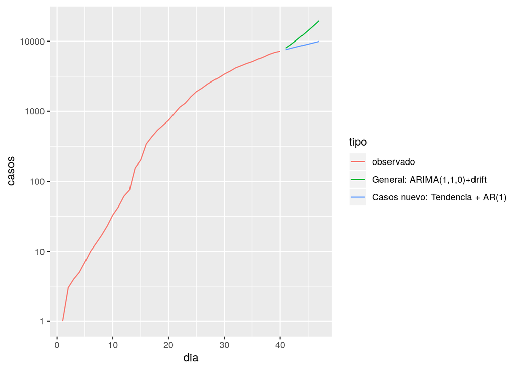

| dia | tipo | casos |
| --- | --- | --- |
| 1 | observado | 1 |
| 2 | observado | 3 |
| 3 | observado | 4 |
| 4 | observado | 5 |
| 5 | observado | 7 |
| 6 | observado | 10 |
| 7 | observado | 13 |
| 8 | observado | 17 |
| 9 | observado | 23 |
| 10 | observado | 33 |
| 11 | observado | 43 |
| 12 | observado | 61 |
| 13 | observado | 75 |
| 14 | observado | 156 |
| 15 | observado | 201 |
| 16 | observado | 342 |
| 17 | observado | 434 |
| 18 | observado | 537 |
| 19 | observado | 632 |
| 20 | observado | 746 |
| 21 | observado | 922 |
| 22 | observado | 1142 |
| 23 | observado | 1306 |
| 24 | observado | 1610 |
| 25 | observado | 1909 |
| 26 | observado | 2139 |
| 27 | observado | 2449 |
| 28 | observado | 2738 |
| 29 | observado | 3031 |
| 30 | observado | 3404 |
| 31 | observado | 3737 |
| 32 | observado | 4161 |
| 33 | observado | 4471 |
| 34 | observado | 4815 |
| 35 | observado | 5116 |
| 36 | observado | 5546 |
| 37 | observado | 5972 |
| 38 | observado | 6501 |
| 39 | observado | 6927 |
| 40 | observado | 7213 |
| 41 | General: ARIMA(1,1,0)+drift | 7991 |
| 42 | General: ARIMA(1,1,0)+drift | 9075 |
| 43 | General: ARIMA(1,1,0)+drift | 10456 |
| 44 | General: ARIMA(1,1,0)+drift | 12161 |
| 45 | General: ARIMA(1,1,0)+drift | 14231 |
| 46 | General: ARIMA(1,1,0)+drift | 16728 |
| 47 | General: ARIMA(1,1,0)+drift | 19729 |
| 41 | Casos nuevo: Tendencia + AR(1) | 7594 |
| 42 | Casos nuevo: Tendencia + AR(1) | 7960 |
| 43 | Casos nuevo: Tendencia + AR(1) | 8334 |
| 44 | Casos nuevo: Tendencia + AR(1) | 8718 |
| 45 | Casos nuevo: Tendencia + AR(1) | 9115 |
| 46 | Casos nuevo: Tendencia + AR(1) | 9533 |
| 47 | Casos nuevo: Tendencia + AR(1) | 9977 |

### Predicción por regiones

Recordemos que el algoritmo inicia desde 3 casos en cada Región .

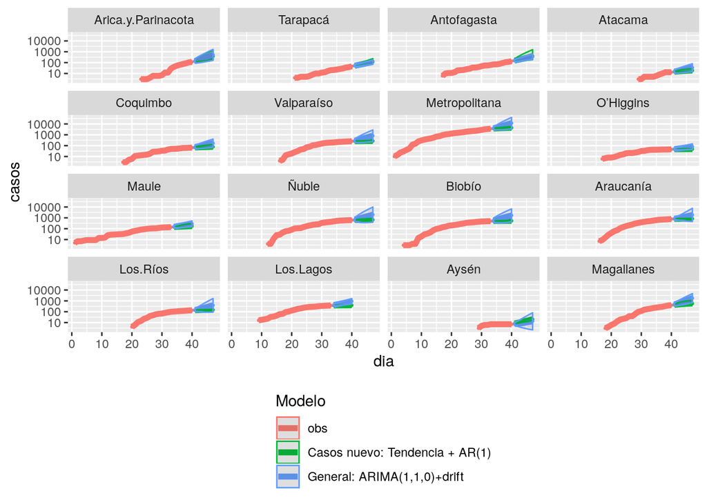

Las tablas por regiones se incluye en el Anexo I

## Decesos

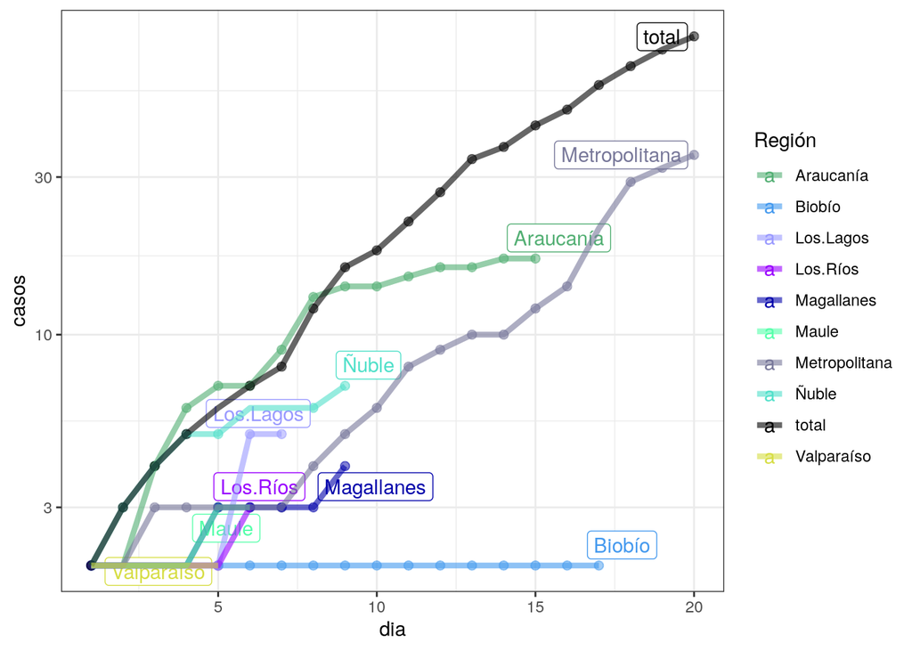

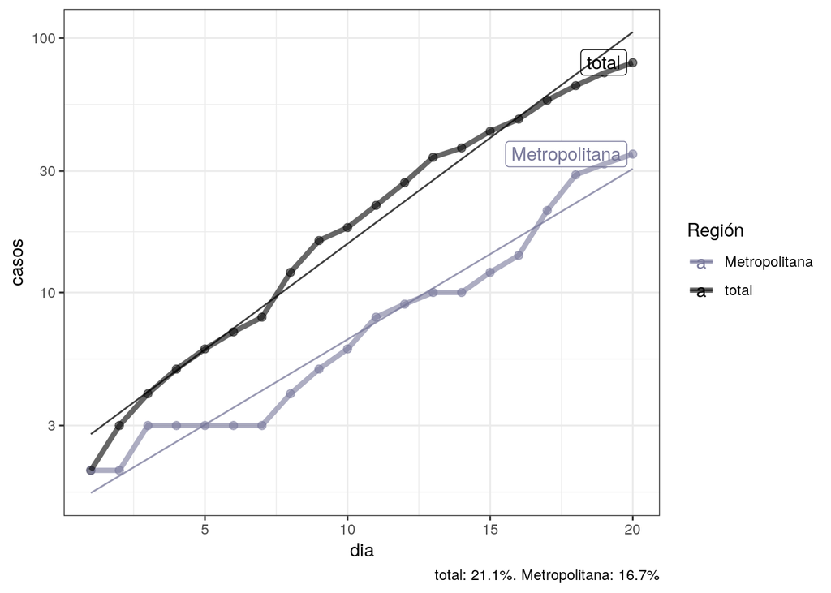

**Fuentes de información**: Principalmente, se utilizó el reporte diario del [MINSAL](https://www.minsal.cl/nuevo-coronavirus-2019-ncov/casos-confirmados-en-chile-covid-19/), usando [Wayback machine](https://archive.org/web/) para recopilar la información ya no disponible.

## Anexo I: Predicciones por región

Casos nuevos: tendencia + AR(1) : Arica.y.Parinacota

|  | dia | casos | li | ls |
| --- | --- | --- | --- | --- |
| **19** | 41 | 138.9 | 120.6 | 217.8 |
| **20** | 42 | 165.1 | 126.6 | 330.9 |
| **21** | 43 | 196.3 | 133.9 | 465.9 |
| **22** | 44 | 233.2 | 142.4 | 625 |
| **23** | 45 | 276.4 | 152.4 | 812 |
| **24** | 46 | 327.1 | 164.1 | 1031 |
| **25** | 47 | 386.2 | 177.8 | 1287 |

Casos nuevos: tendencia + AR(1) : Tarapacá

|  | dia | casos | li | ls |
| --- | --- | --- | --- | --- |
| **21** | 41 | 51.45 | 48.38 | 58.48 |
| **22** | 42 | 59 | 51.56 | 76.37 |
| **23** | 43 | 67.59 | 55.18 | 96.79 |
| **24** | 44 | 78.05 | 59.58 | 121.7 |
| **25** | 45 | 90.64 | 64.88 | 151.6 |
| **26** | 46 | 106 | 71.34 | 188.1 |
| **27** | 47 | 124.9 | 79.27 | 232.9 |

Casos nuevos: tendencia + AR(1) : Antofagasta

|  | dia | casos | li | ls |
| --- | --- | --- | --- | --- |
| **25** | 41 | 153.7 | 141.1 | 218.8 |
| **26** | 42 | 175.7 | 145.1 | 338.3 |
| **27** | 43 | 202.1 | 149.9 | 482.3 |
| **28** | 44 | 235.5 | 156.1 | 664.5 |
| **29** | 45 | 277.7 | 163.8 | 894.4 |
| **30** | 46 | 331.5 | 173.7 | 1188 |
| **31** | 47 | 400.9 | 186.4 | 1566 |

Casos nuevos: tendencia + AR(1) : Atacama

|  | dia | casos | li | ls |
| --- | --- | --- | --- | --- |
| **13** | 41 | 14.14 | 13.45 | 15.89 |
| **14** | 42 | 15.19 | 13.86 | 18.57 |
| **15** | 43 | 16.12 | 14.22 | 20.95 |
| **16** | 44 | 16.92 | 14.54 | 23.01 |
| **17** | 45 | 17.61 | 14.81 | 24.75 |
| **18** | 46 | 18.17 | 15.03 | 26.2 |
| **19** | 47 | 18.64 | 15.21 | 27.38 |

Casos nuevos: tendencia + AR(1) : Coquimbo

|  | dia | casos | li | ls |
| --- | --- | --- | --- | --- |
| **25** | 41 | 68.11 | 66.44 | 76.23 |
| **26** | 42 | 70.08 | 66.83 | 86.01 |
| **27** | 43 | 71.94 | 67.21 | 95.27 |
| **28** | 44 | 73.69 | 67.56 | 103.9 |
| **29** | 45 | 75.31 | 67.88 | 112 |
| **30** | 46 | 76.81 | 68.19 | 119.4 |
| **31** | 47 | 78.18 | 68.46 | 126.3 |

Casos nuevos: tendencia + AR(1) : Valparaíso

|  | dia | casos | li | ls |
| --- | --- | --- | --- | --- |
| **26** | 41 | 257.8 | 255.4 | 264.3 |
| **27** | 42 | 261.1 | 256.5 | 274.1 |
| **28** | 43 | 263.5 | 257.3 | 281.4 |
| **29** | 44 | 265.4 | 257.9 | 287 |
| **30** | 45 | 266.7 | 258.4 | 291.1 |
| **31** | 46 | 267.7 | 258.7 | 294.1 |
| **32** | 47 | 268.4 | 258.9 | 296.2 |

Casos nuevos: tendencia + AR(1) : Metropolitana

|  | dia | casos | li | ls |
| --- | --- | --- | --- | --- |
| **34** | 34 | 3750 | 3659 | 3980 |
| **35** | 35 | 3892 | 3714 | 4347 |
| **36** | 36 | 4024 | 3765 | 4686 |
| **37** | 37 | 4144 | 3812 | 4996 |
| **38** | 38 | 4252 | 3854 | 5275 |
| **39** | 39 | 4349 | 3891 | 5525 |
| **40** | 40 | 4435 | 3924 | 5746 |

Casos nuevos: tendencia + AR(1) : O’Higgins

|  | dia | casos | li | ls |
| --- | --- | --- | --- | --- |
| **25** | 41 | 46.58 | 46.2 | 47.7 |
| **26** | 42 | 47.06 | 46.36 | 49.08 |
| **27** | 43 | 47.43 | 46.49 | 50.16 |
| **28** | 44 | 47.72 | 46.59 | 51 |
| **29** | 45 | 47.93 | 46.66 | 51.64 |
| **30** | 46 | 48.1 | 46.72 | 52.11 |
| **31** | 47 | 48.22 | 46.76 | 52.46 |

Casos nuevos: tendencia + AR(1) : Maule

|  | dia | casos | li | ls |
| --- | --- | --- | --- | --- |
| **34** | 34 | 142.7 | 139 | 160.1 |
| **35** | 35 | 147.6 | 140 | 183.9 |
| **36** | 36 | 152.5 | 141 | 207.5 |
| **37** | 37 | 157.2 | 142 | 230.7 |
| **38** | 38 | 161.8 | 142.9 | 253.2 |
| **39** | 39 | 166.3 | 143.8 | 275 |
| **40** | 40 | 170.6 | 144.7 | 296 |

Casos nuevos: tendencia + AR(1) : Ñuble

|  | dia | casos | li | ls |
| --- | --- | --- | --- | --- |
| **30** | 41 | 626.1 | 615.9 | 672.2 |
| **31** | 42 | 636.5 | 618.2 | 719.1 |
| **32** | 43 | 645.2 | 620.1 | 758.6 |
| **33** | 44 | 652.3 | 621.7 | 791 |
| **34** | 45 | 658.1 | 623 | 817.3 |
| **35** | 46 | 662.8 | 624 | 838.3 |
| **36** | 47 | 666.4 | 624.8 | 854.9 |

Casos nuevos: tendencia + AR(1) : Biobío

|  | dia | casos | li | ls |
| --- | --- | --- | --- | --- |
| **31** | 34 | 508.4 | 503.4 | 521.2 |
| **32** | 35 | 515 | 505.9 | 537.8 |
| **33** | 36 | 520 | 507.9 | 550.5 |
| **34** | 37 | 523.8 | 509.4 | 560 |
| **35** | 38 | 526.5 | 510.5 | 566.9 |
| **36** | 39 | 528.5 | 511.3 | 571.9 |
| **37** | 40 | 529.9 | 511.8 | 575.3 |

Casos nuevos: tendencia + AR(1) : Araucanía

|  | dia | casos | li | ls |
| --- | --- | --- | --- | --- |
| **26** | 41 | 792.8 | 784 | 810.1 |
| **27** | 42 | 806.2 | 790.8 | 836.7 |
| **28** | 43 | 816.5 | 796 | 857 |
| **29** | 44 | 824.2 | 799.9 | 872.2 |
| **30** | 45 | 829.8 | 802.7 | 883.3 |
| **31** | 46 | 833.8 | 804.7 | 891.2 |
| **32** | 47 | 836.5 | 806.1 | 896.7 |

Casos nuevos: tendencia + AR(1) : Los.Ríos

|  | dia | casos | li | ls |
| --- | --- | --- | --- | --- |
| **22** | 41 | 138.2 | 136.4 | 142.3 |
| **23** | 42 | 141 | 137.7 | 148.5 |
| **24** | 43 | 143.3 | 138.7 | 153.6 |
| **25** | 44 | 145.1 | 139.5 | 157.6 |
| **26** | 45 | 146.5 | 140.1 | 160.8 |
| **27** | 46 | 147.6 | 140.6 | 163.3 |
| **28** | 47 | 148.5 | 141 | 165.2 |

Casos nuevos: tendencia + AR(1) : Los.Lagos

|  | dia | casos | li | ls |
| --- | --- | --- | --- | --- |
| **26** | 34 | 378.5 | 374.6 | 388.2 |
| **27** | 35 | 383.5 | 376.5 | 401.6 |
| **28** | 36 | 387.2 | 377.8 | 411.8 |
| **29** | 37 | 389.9 | 378.8 | 419.2 |
| **30** | 38 | 391.8 | 379.5 | 424.5 |
| **31** | 39 | 393.1 | 379.9 | 428.2 |
| **32** | 40 | 394 | 380.3 | 430.7 |

Casos nuevos: tendencia + AR(1) : Aysén

|  | dia | casos | li | ls |
| --- | --- | --- | --- | --- |
| **13** | 41 | 8.22 | 7.88 | 8.69 |
| **14** | 42 | 9.51 | 8.79 | 10.52 |
| **15** | 43 | 11 | 9.83 | 12.65 |
| **16** | 44 | 12.71 | 11.03 | 15.09 |
| **17** | 45 | 14.72 | 12.44 | 17.98 |
| **18** | 46 | 17.14 | 14.13 | 21.44 |
| **19** | 47 | 20.11 | 16.2 | 25.68 |

Casos nuevos: tendencia + AR(1) : Magallanes

|  | dia | casos | li | ls |
| --- | --- | --- | --- | --- |
| **24** | 41 | 430 | 404.7 | 529.5 |
| **25** | 42 | 457.7 | 411.4 | 643.8 |
| **26** | 43 | 485.2 | 418 | 757.9 |
| **27** | 44 | 510.5 | 424.1 | 862.9 |
| **28** | 45 | 533.8 | 429.7 | 959.6 |
| **29** | 46 | 554.9 | 434.8 | 1047 |
| **30** | 47 | 573.6 | 439.3 | 1125 |

ARIMA(1,1,0) con deriva : Arica.y.Parinacota

|  | dia | casos | li | ls |
| --- | --- | --- | --- | --- |
| **19** | 41 | 143.8 | 90.55 | 228.5 |
| **20** | 42 | 178.4 | 94.4 | 337 |
| **21** | 43 | 221.3 | 102.2 | 479.1 |
| **22** | 44 | 274.5 | 113 | 667.2 |
| **23** | 45 | 340.6 | 126.5 | 916.9 |
| **24** | 46 | 422.5 | 143.1 | 1248 |
| **25** | 47 | 524.2 | 163 | 1686 |

ARIMA(1,1,0) con deriva : Tarapacá

|  | dia | casos | li | ls |
| --- | --- | --- | --- | --- |
| **21** | 41 | 51.86 | 43.07 | 62.45 |
| **22** | 42 | 59.08 | 46.28 | 75.42 |
| **23** | 43 | 67.2 | 50.12 | 90.11 |
| **24** | 44 | 76.45 | 54.69 | 106.9 |
| **25** | 45 | 86.98 | 59.95 | 126.2 |
| **26** | 46 | 98.96 | 65.94 | 148.5 |
| **27** | 47 | 112.6 | 72.72 | 174.3 |

ARIMA(1,1,0) con deriva : Antofagasta

|  | dia | casos | li | ls |
| --- | --- | --- | --- | --- |
| **25** | 41 | 156.5 | 123.4 | 198.6 |
| **26** | 42 | 179.1 | 132.4 | 242.2 |
| **27** | 43 | 204.5 | 142.6 | 293.3 |
| **28** | 44 | 233.7 | 155.1 | 352 |
| **29** | 45 | 266.9 | 169.6 | 420.2 |
| **30** | 46 | 304.9 | 186.1 | 499.7 |
| **31** | 47 | 348.4 | 204.8 | 592.5 |

ARIMA(1,1,0) con deriva : Atacama

|  | dia | casos | li | ls |
| --- | --- | --- | --- | --- |
| **13** | 41 | 15.17 | 10.64 | 21.63 |
| **14** | 42 | 17.34 | 10.85 | 27.72 |
| **15** | 43 | 19.88 | 11.31 | 34.95 |
| **16** | 44 | 22.78 | 11.95 | 43.43 |
| **17** | 45 | 26.1 | 12.74 | 53.47 |
| **18** | 46 | 29.91 | 13.68 | 65.41 |
| **19** | 47 | 34.28 | 14.76 | 79.6 |

ARIMA(1,1,0) con deriva : Coquimbo

|  | dia | casos | li | ls |
| --- | --- | --- | --- | --- |
| **25** | 41 | 75.36 | 54.47 | 104.2 |
| **26** | 42 | 86.18 | 54.25 | 136.9 |
| **27** | 43 | 98.56 | 55.83 | 174 |
| **28** | 44 | 112.7 | 58.43 | 217.4 |
| **29** | 45 | 128.9 | 61.79 | 268.9 |
| **30** | 46 | 147.4 | 65.85 | 330 |
| **31** | 47 | 168.6 | 70.58 | 402.8 |

ARIMA(1,1,0) con deriva : Valparaíso

|  | dia | casos | li | ls |
| --- | --- | --- | --- | --- |
| **26** | 41 | 293 | 199.1 | 431.1 |
| **27** | 42 | 345.9 | 189.3 | 632 |
| **28** | 43 | 410.4 | 190.2 | 885.5 |
| **29** | 44 | 487.3 | 196.7 | 1207 |
| **30** | 45 | 578.7 | 207.3 | 1616 |
| **31** | 46 | 687.2 | 221.1 | 2136 |
| **32** | 47 | 816.2 | 238.1 | 2798 |

ARIMA(1,1,0) con deriva : Metropolitana

|  | dia | casos | li | ls |
| --- | --- | --- | --- | --- |
| **34** | 34 | 4085 | 3023 | 5520 |
| **35** | 35 | 4798 | 2854 | 8066 |
| **36** | 36 | 5714 | 2830 | 11536 |
| **37** | 37 | 6843 | 2900 | 16146 |
| **38** | 38 | 8213 | 3039 | 22199 |
| **39** | 39 | 9868 | 3235 | 30097 |
| **40** | 40 | 11860 | 3485 | 40362 |

ARIMA(1,1,0) con deriva : O’Higgins

|  | dia | casos | li | ls |
| --- | --- | --- | --- | --- |
| **25** | 41 | 48.96 | 42.29 | 56.67 |
| **26** | 42 | 52.94 | 41.18 | 68.05 |
| **27** | 43 | 57.6 | 41.07 | 80.79 |
| **28** | 44 | 62.84 | 41.6 | 94.9 |
| **29** | 45 | 68.61 | 42.59 | 110.5 |
| **30** | 46 | 74.94 | 43.94 | 127.8 |
| **31** | 47 | 81.87 | 45.57 | 147.1 |

ARIMA(1,1,0) con deriva : Maule

|  | dia | casos | li | ls |
| --- | --- | --- | --- | --- |
| **34** | 34 | 154 | 120.4 | 196.8 |
| **35** | 35 | 170.6 | 122.3 | 238.1 |
| **36** | 36 | 189.2 | 126.5 | 283.1 |
| **37** | 37 | 209.8 | 132.1 | 333.1 |
| **38** | 38 | 232.6 | 139 | 389.3 |
| **39** | 39 | 257.9 | 147 | 452.7 |
| **40** | 40 | 286 | 156 | 524.5 |

ARIMA(1,1,0) con deriva : Ñuble

|  | dia | casos | li | ls |
| --- | --- | --- | --- | --- |
| **30** | 41 | 697.5 | 439 | 1108 |
| **31** | 42 | 820.3 | 386.7 | 1740 |
| **32** | 43 | 973.7 | 365.3 | 2596 |
| **33** | 44 | 1159 | 359.5 | 3735 |
| **34** | 45 | 1380 | 363.1 | 5244 |
| **35** | 46 | 1644 | 373.5 | 7234 |
| **36** | 47 | 1958 | 389.3 | 9849 |

ARIMA(1,1,0) con deriva : Biobío

|  | dia | casos | li | ls |
| --- | --- | --- | --- | --- |
| **31** | 34 | 586.8 | 362.9 | 949 |
| **32** | 35 | 698.2 | 342.1 | 1425 |
| **33** | 36 | 831.8 | 341.6 | 2025 |
| **34** | 37 | 991 | 351.4 | 2795 |
| **35** | 38 | 1181 | 368.1 | 3787 |
| **36** | 39 | 1407 | 390.6 | 5067 |
| **37** | 40 | 1676 | 418.6 | 6713 |

ARIMA(1,1,0) con deriva : Araucanía

|  | dia | casos | li | ls |
| --- | --- | --- | --- | --- |
| **26** | 41 | 836.2 | 694.8 | 1006 |
| **27** | 42 | 922.8 | 630.8 | 1350 |
| **28** | 43 | 1037 | 575.7 | 1867 |
| **29** | 44 | 1181 | 531.2 | 2627 |
| **30** | 45 | 1361 | 496.8 | 3730 |
| **31** | 46 | 1583 | 471.2 | 5316 |
| **32** | 47 | 1853 | 453.1 | 7580 |

ARIMA(1,1,0) con deriva : Los.Ríos

|  | dia | casos | li | ls |
| --- | --- | --- | --- | --- |
| **22** | 41 | 148.5 | 113.6 | 194.1 |
| **23** | 42 | 169.1 | 101.9 | 280.4 |
| **24** | 43 | 196.5 | 94.69 | 407.8 |
| **25** | 44 | 231.3 | 90.78 | 589.4 |
| **26** | 45 | 274.3 | 89.32 | 842.6 |
| **27** | 46 | 326.8 | 89.77 | 1190 |
| **28** | 47 | 390.4 | 91.76 | 1661 |

ARIMA(1,1,0) con deriva : Los.Lagos

|  | dia | casos | li | ls |
| --- | --- | --- | --- | --- |
| **26** | 34 | 421.1 | 343.4 | 516.3 |
| **27** | 35 | 479.6 | 356.2 | 645.9 |
| **28** | 36 | 546.6 | 378.1 | 790.4 |
| **29** | 37 | 623 | 406 | 956 |
| **30** | 38 | 710 | 439.2 | 1148 |
| **31** | 39 | 809.2 | 477.6 | 1371 |
| **32** | 40 | 922.2 | 521.3 | 1632 |

ARIMA(1,1,0) con deriva : Aysén

|  | dia | casos | li | ls |
| --- | --- | --- | --- | --- |
| **13** | 41 | 7.28 | 5.47 | 9.69 |
| **14** | 42 | 7.78 | 4.43 | 13.67 |
| **15** | 43 | 8.48 | 3.66 | 19.65 |
| **16** | 44 | 9.37 | 3.1 | 28.32 |
| **17** | 45 | 10.44 | 2.68 | 40.57 |
| **18** | 46 | 11.71 | 2.38 | 57.58 |
| **19** | 47 | 13.19 | 2.15 | 80.84 |

ARIMA(1,1,0) con deriva : Magallanes

|  | dia | casos | li | ls |
| --- | --- | --- | --- | --- |
| **24** | 41 | 478.2 | 352.9 | 647.8 |
| **25** | 42 | 592.7 | 369.9 | 949.8 |
| **26** | 43 | 738.3 | 405.1 | 1346 |
| **27** | 44 | 920.6 | 454 | 1867 |
| **28** | 45 | 1148 | 516 | 2554 |
| **29** | 46 | 1432 | 592.2 | 3462 |
| **30** | 47 | 1786 | 684.5 | 4658 |